# Telling Stories With Data: Showing Disparities in a Continuous Risk Factor

Andy Grogan-Kaylor

2019-07-03

# 1 Background

In this document, I am trying to think through some best practices in showing disparities in a *continuous risk factor*, like *levels of depression* or *levels of poverty*.

> I am using the graphing library `ggplot`. As I often do, I am going to show the code. The code can be useful, especially if you are trying to replicate some of these graphs. However, the discussion is intended to be more conceptual, and you do not need to understand the code to follow the discussion. Indeed, the discussion is intended to be applicable to a wide variety of data visualization tools, including those that do not rely on coding.

I’m going to start by imagining that we have different groups of people.

| Group A | Group B | Group C |
| --- | --- | --- |
| 47 | 38 | 15 |

We’re going to set up our graphing commands, which requires using some code.

```r
library(ggplot2) # beautiful graphs

library(ggbeeswarm) # "beeswarm" geometry
```

# 2 Grammar of Graphics

Let’s think a little bit about a *grammar of graphics*: What are we going to graph, and how might we wish to represent those quantities on the graph?

In this example, we are graphing *group* and *risk*. In this example, I am going to use the *x axis* for the groups, and the *y axis* for risk.

And then I’m going to think about how I draw the information, which `ggplot` the graphing library that I am using, calls *geometries.* To start with, I’m going to use perhaps the most intuitive, or at least the most common, geometry of *bars.*

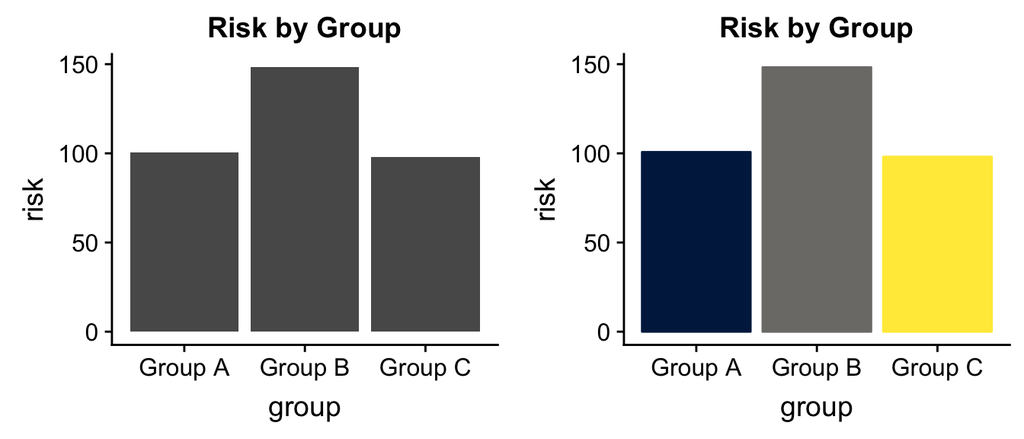

Two Philosophies

Here, right away, we are presented with two competing philosophies of the *grammar of graphics*. A *minimalist* philosophy, represented on the left hand side, would say that we shouldn’t add extra detail to the graph unless it adds extra information.

So, this philosophy would say that, as we outlined above, *group* goes on the x axis and *risk* goes on the y axis. We wouldn’t add extra detail, like *color* to the graph because we’ve already encoded both *group* and *risk*.

An alternative philosophy, represented on the right hand side, might say that for *visual interest* we can add extra detail, like *color* even if it doesn’t necessarily add extra information to the graph.

> In this document, I’m going err on the side of making my graphs more visually interesting, although I certainly understand the *minimalist* philosophy.

# 3 A More Visually Interesting Grammatical Statement

In the graphs below, *group* will again go on the x axis. *Risk* will go on the y axis. In drawing this information in various ways–employing various geometries–I am going use colors (the *Viridis* color palettes) for fill and color.

These decisions are echoed in the (admittedly complicated) `ggplot` code below which sets up the graphs to follow. Again, however, it’s not necessary to follow the code to follow the discussion.

```r
myplot <- ggplot(data = mydata,
       aes(x = group, # x is the group
           fill = group, # fill is the group
           color = group, # color is the group
           y = risk)) + # y is risk
  labs(title = "Risk by Group") + # labels
  scale_color_viridis_d(option = "cividis") + # discrete viridis colors
  scale_fill_viridis_d(option = "cividis") # discrete viridis fills
```

# 4 Examples

Now that I’ve thought through the grammar of graphics, I can try different geometries, and think about how well they tell the story that I want to tell.

> While `ggplot` code is provided, you can ignore the code if you like.

## 4.1 Bar Graph

As noted above, a bar graph might be the most intuitive, or at least the most common approach. Note that because the bars are the *mean* of risk scores for different groups, that we have to make this clear in the code.

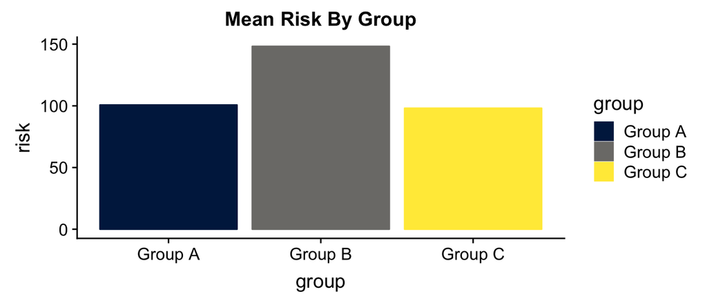

```r
myplot + stat_summary(fun.y = mean, geom = "bar") +
  labs(title = "Mean Risk By Group")
```

## 4.2 Points at Mean Values

Instead of bars indicating mean risk, we could use points at the mean risk value for each group.

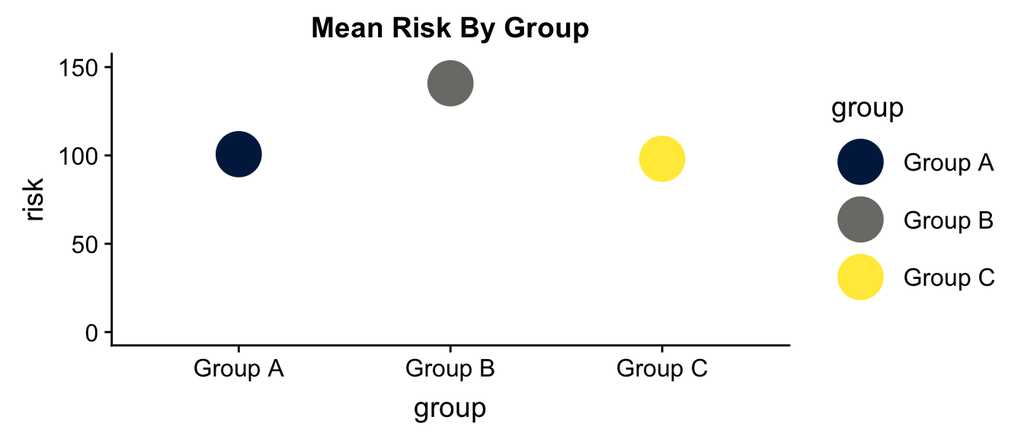

```r
myplot +
  stat_summary(fun.y = mean, geom = "point", size = 10) +
  ylim(0,150) +
  labs(title = "Mean Risk By Group")
```

## 4.3 Points at Mean Values Connected by Line

Perhaps we connect the points with a line. Connecting the points with a line in this way may be confusing, as it may imply some kind of trend that we do not wish to imply.

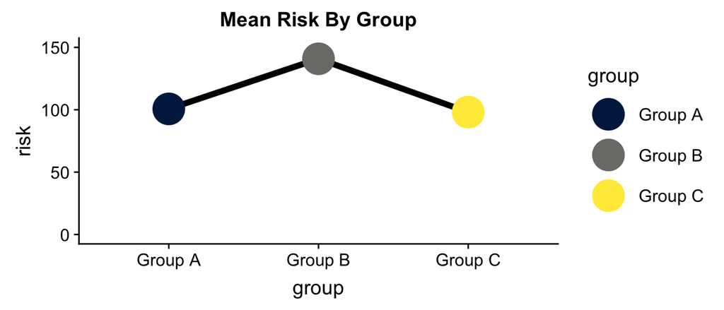

Points at Mean Values

```r
myplot +
  stat_summary(fun.y = mean, geom = "line",
               group = 1,
               color = "black", size = 2) +
  stat_summary(fun.y = mean, geom = "point", size = 10) +
  ylim(0,150) +
  labs(title = "Mean Risk By Group")
```

## 4.4 “Lollipop” Chart

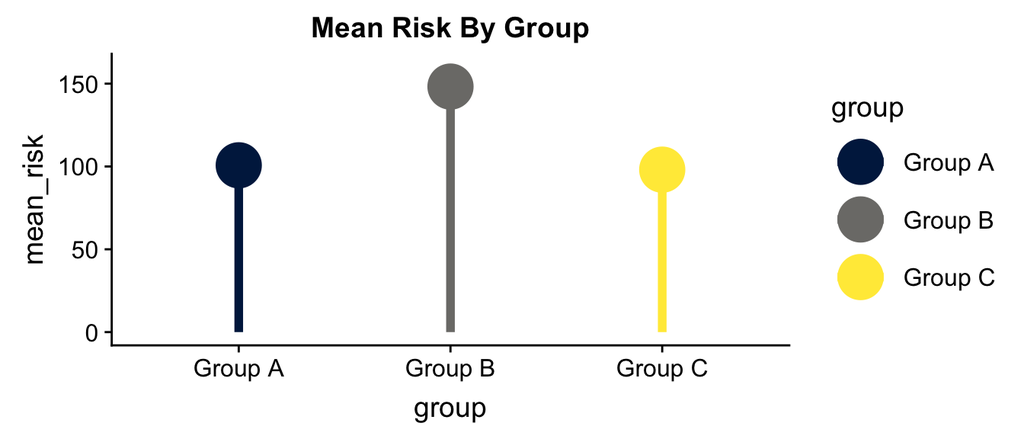

Lollipop Chart

```r
# In order to draw the segments of the lollipops,
# we have to summarize the data with dplyr,
# and 'pipe' into ggplot

library(dplyr) # data wrangling

mydata %>%
  group_by(group) %>% # group by group
  summarise(mean_risk = mean(risk)) %>% # summarize by group
  ggplot(aes(x = group,
             y = mean_risk,
             color = group)) +
  geom_point(size = 10) +
  geom_segment(aes(x = group,
                   xend = group,
                   y = 0,
                   yend = mean_risk),
               size = 2) +
  ylim(0,160) +
  scale_color_viridis_d(option = "cividis") +
  labs(title = "Mean Risk By Group")
```

## 4.5 Points

There are various geometries that make use of points to show the full range of the data.

I think that bars may be the best if we wish to focus on differences in group *averages*. However, there is something very intuitive about graphs where each individual person is represented by an individual point.

Additionally, points give us a better idea of the exact nature of how risk is distributed, and the highest and lowest values of risk for each group.

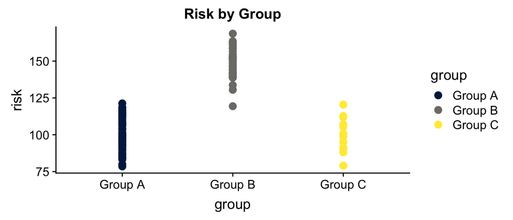

Points

```r
myplot + geom_point(size = 3) # simple points
```

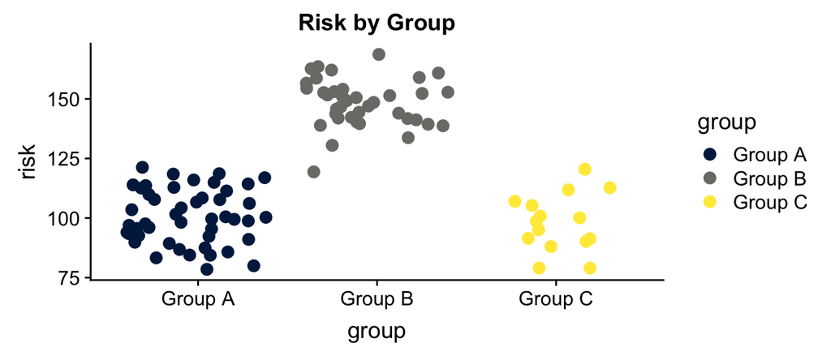

Jittered Points

```r
myplot +  geom_jitter(size = 3) # jittered points
```

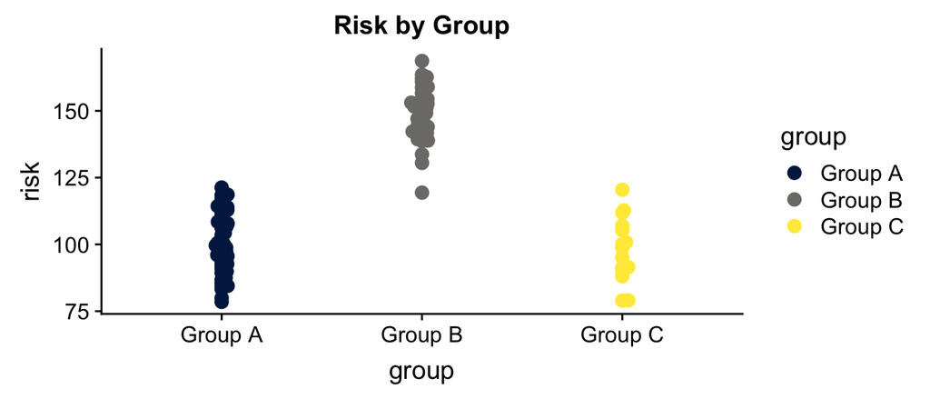

Beeswarm

```r
myplot + geom_beeswarm(size = 3) # beeswarm geometry
```

Personally, I like the compact nature of the *beeswarm* geometry, but that may be a matter of personal preference.

# 5 Alternative Geometries

There are some alternative, less commonly employed geometries. I’ve seen boxplots a lot in statistics textbooks, but not so much elswhere. Personally, I find boxplots to be less intuitive.

## 5.1 Boxplot

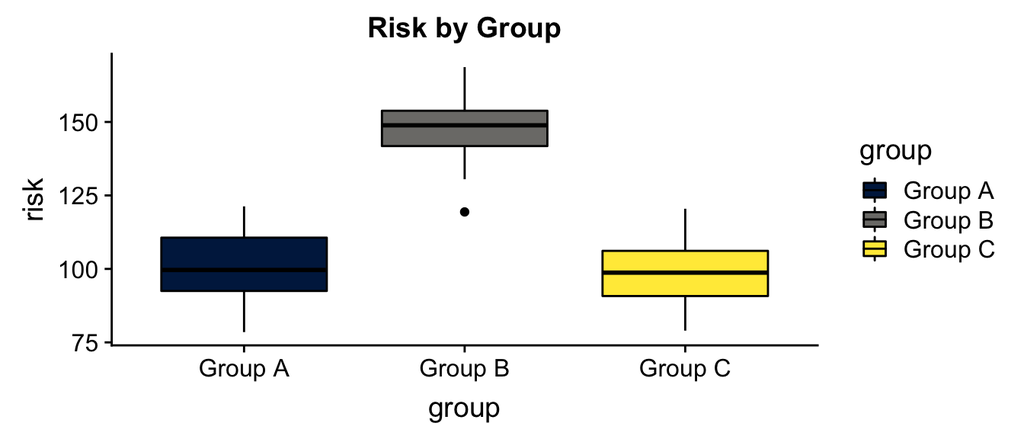

Boxplot

```r
myplot + geom_boxplot(color = "black") # boxplot
```

## 5.2 Violin Plot

An even more rarely used geometry is the *violin plot*. It has the advantage of being visually striking, but seems to be less intuitively interpretable.

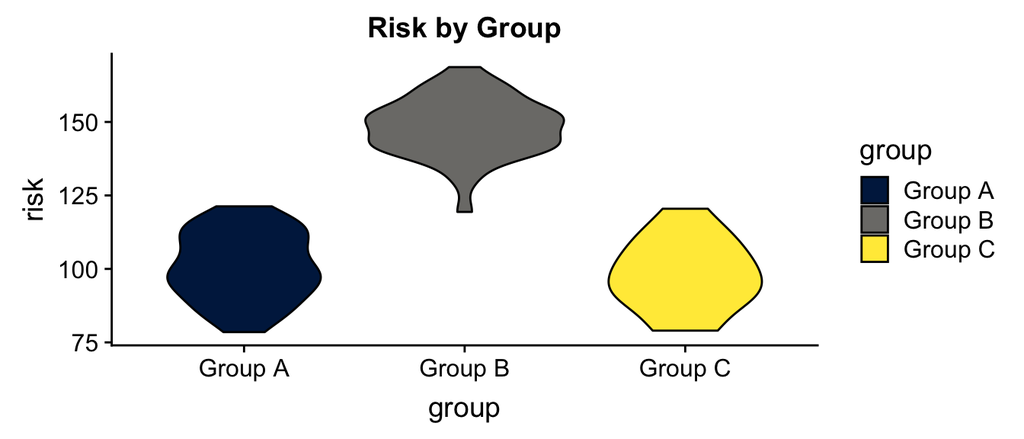

Violin Plot

```r
myplot + geom_violin(color = "black") # violin plot
```

# 6 Thinking More About Color

Above, we added color to the graph simply to add visual interest. We may wish to manually tweak the colors, to emphasize the level of risk faced by a particular group or groups.

This of course requires slightly more complicated code to tweak the colors.

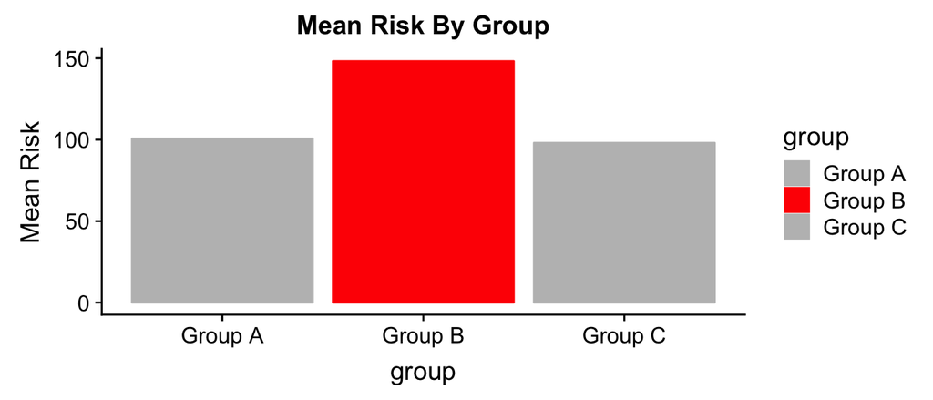

```r
myplot + stat_summary(fun.y = mean, geom = "bar") +
  labs(title = "Mean Risk By Group",
       y = "Mean Risk") +
  scale_color_manual(values = c("grey", "red", "grey")) +
  scale_fill_manual(breaks = c("Group A",
                               "Group B",
                               "Group C"),
                    values = c("grey", "red", "grey"))
```

# 7 Thinking More About Titles and Labels

In addition to thinking about manually specifying colors to tell a story that is more clear, we may also wish to think about the titles.

We may wish to modify the title to be less studiously neutral, and to encapsulate the *key takeway* that we wish our audience to get.

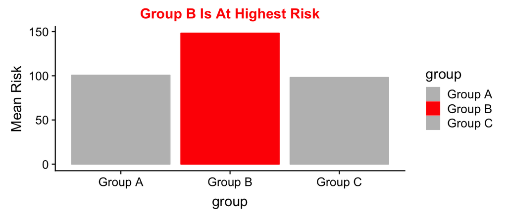

```r
myplot + stat_summary(fun.y = mean, geom = "bar") +
  labs(title = "Group B Is At Highest Risk",
       y = "Mean Risk") +
  scale_color_manual(values = c("grey", "red", "grey")) +
  scale_fill_manual(breaks = c("Group A",
                               "Group B",
                               "Group C"),
                    values = c("grey", "red", "grey")) +
  theme(plot.title = element_text(color = "red"))
```

# 8 Add A Big Number

We can add a big number as a data label and for emphasis.

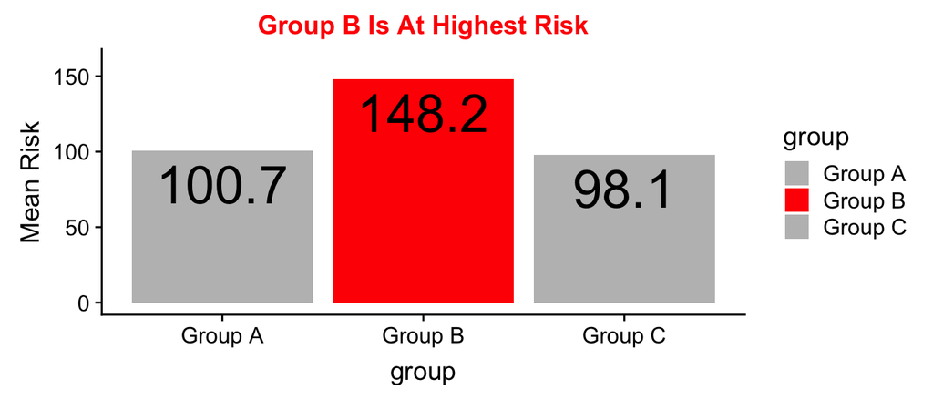

```r
library(dplyr) # data wrangling

mydata %>%
  group_by(group) %>% # group by group
  # summarize by group
  summarise(mean_risk = round(mean(risk),
                              digits = 1)) %>%
  ggplot(aes(x = group,
             y = mean_risk,
             fill = group,
             label = mean_risk)) +
  geom_bar(stat = "identity") + # y is actual bar height
  geom_text(aes(y = mean_risk - 10), # placement
            vjust = 1, # vertical justification
            size = 10) +
  ylim(0,160) +
  scale_color_manual(values = c("grey", "red", "grey")) +
  scale_fill_manual(breaks = c("Group A",
                               "Group B",
                               "Group C"),
                    values = c("grey", "red", "grey")) +
  labs(title = "Group B Is At Highest Risk",
       y = "Mean Risk") +
    theme(plot.title = element_text(color = "red"))
```

# 9 Rotate The Bar Chart

Lastly, we can think about rotating the bar chart to improve readability.

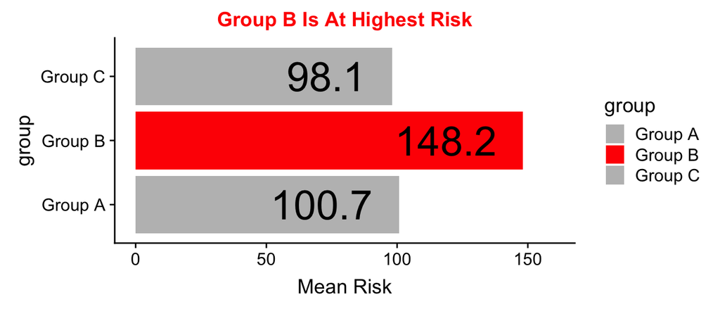

```r
library(dplyr) # data wrangling

mydata %>%
  group_by(group) %>% # group by group
  # summarize by group
  summarise(mean_risk = round(mean(risk),
                              digits = 1)) %>%
  ggplot(aes(x = group,
             y = mean_risk,
             fill = group,
             label = mean_risk)) +
  geom_bar(stat = "identity") + # y is actual bar height
  geom_text(aes(y = mean_risk - 10), # placement
            vjust = .5, # vertical justification
            hjust = 1, # horizontal justification
            size = 10) +
  ylim(0,160) +
  scale_color_manual(values = c("grey", "red", "grey")) +
  scale_fill_manual(breaks = c("Group A",
                               "Group B",
                               "Group C"),
                    values = c("grey", "red", "grey")) +
  labs(title = "Group B Is At Highest Risk",
       y = "Mean Risk") +
  theme(plot.title = element_text(color = "red")) +
  coord_flip()
```

# 10 Conclusion

Graphing disparities in risk, whether using a code based graphing program like `ggplot` or a more *drag and drop* program requires careful decision making.

We need to think initially about a *grammar of graphics* and how we are going to encode our data. We need to think about whether we have a *minimalist* philosophy of *grammar of graphics* or one that focuses more on *visual interest*.

We then need to try out various *geometries* to see which geometries make our stories the most clear.

We should consider devoting some attention to manual manipulation of choice of color. Making our titles and labels more clear may also help us to better tell our story.